# Practical Machine Learning Course Project

Yasukazu IKAMI

Sunday, May 24, 2015

# Summary

This analysis is the prediction of “how well” subjects do the dumbell lifting exercises. Using the accelerometer data mounted on dumbell, forearm, arm, belt, prediction of the exercise class was executed. Exercise data source are from:http://groupware.les.inf.puc-rio.br/har.

# Loading data

```r
#training set
if(!file.exists("pml-training.csv")){
    trurl <- "http://d396qusza40orc.cloudfront.net/predmachlearn/pml-training.csv"
    download.file(url=trurl,destfile = "pml-training.csv")
    }
if(!file.exists("pml-testing.csv")){
    teurl <- "http://d396qusza40orc.cloudfront.net/predmachlearn/pml-testing.csv"
    download.file(url=teurl,destfile = "pml-testing.csv")
}
training <- read.csv("pml-training.csv",
                     na.strings=c("NA","#DIV/0!",""))
testing  <- read.csv("pml-testing.csv",
                     na.strings=c("NA","#DIV/0!",""))
```

# Preprocessing

## Overview of the training data

```r
names(training)
```

```
##   [1] "X"                        "user_name"
##   [3] "raw_timestamp_part_1"     "raw_timestamp_part_2"
##   [5] "cvtd_timestamp"           "new_window"
##   [7] "num_window"               "roll_belt"
##   [9] "pitch_belt"               "yaw_belt"
##  [11] "total_accel_belt"         "kurtosis_roll_belt"
##  [13] "kurtosis_picth_belt"      "kurtosis_yaw_belt"
##  [15] "skewness_roll_belt"       "skewness_roll_belt.1"
##  [17] "skewness_yaw_belt"        "max_roll_belt"
##  [19] "max_picth_belt"           "max_yaw_belt"
##  [21] "min_roll_belt"            "min_pitch_belt"
##  [23] "min_yaw_belt"             "amplitude_roll_belt"
##  [25] "amplitude_pitch_belt"     "amplitude_yaw_belt"
##  [27] "var_total_accel_belt"     "avg_roll_belt"
##  [29] "stddev_roll_belt"         "var_roll_belt"
```

[output cut: 65 more lines]

Because columns 1 to 7 are not accelerometer data, they are excluded by the learning material. And to construct learning algorithm all the variables are converted into numerical except for output ‘classe’ variable.

```r
endc <- length(training)
training <- training[,8:endc]
testing  <- testing[,8:endc]

endc <- length(training)-1
for(i in 1:endc){
    training[,i] <- as.numeric(training[,i])
    testing[,i] <- as.numeric(testing[,i])
    }
```

## Simplifing variables

```r
randomlist <- sort.list(training[,4])
training <- training[randomlist,]
```

Counting NA’s of predictors.

```r
endc <- length(training)
nas <- NULL
for (i in 1:endc){
    nas[i] <- sum(is.na(training[,i]))
    }
nas
```

```
##   [1]     0     0     0     0 19226 19248 19622 19225 19248 19622 19216
##  [12] 19216 19226 19216 19216 19226 19216 19216 19226 19216 19216 19216
##  [23] 19216 19216 19216 19216 19216 19216 19216     0     0     0     0
##  [34]     0     0     0     0     0     0     0     0     0 19216 19216
##  [45] 19216 19216 19216 19216 19216 19216 19216 19216     0     0     0
##  [56]     0     0     0     0     0     0 19294 19296 19227 19293 19296
##  [67] 19227 19216 19216 19216 19216 19216 19216 19216 19216 19216     0
##  [78]     0     0 19221 19218 19622 19220 19217 19622 19216 19216 19221
##  [89] 19216 19216 19221 19216 19216 19221     0 19216 19216 19216 19216
## [100] 19216 19216 19216 19216 19216 19216     0     0     0     0     0
## [111]     0     0     0     0     0     0     0 19300 19301 19622 19299
## [122] 19301 19622 19216 19216 19300 19216 19216 19300 19216 19216 19300
## [133]     0 19216 19216 19216 19216 19216 19216 19216 19216 19216 19216
## [144]     0     0     0     0     0     0     0     0     0     0
```

```r
removecol <- which(nas > 19000)
training <- training[,-removecol]
testing  <- testing[,-removecol]
```

Remove one of pair variables that has correlation value greater than 0.9.

```r
library(caret)
endc <- length(training)
correl <- cor(training[,-endc])
removecol <- findCorrelation(correl,cutoff=0.9)
training <- training[,-removecol]
testing  <- testing[,-removecol]
```

# Model building

## SVM algorithm

First, I use SVM algorithm to build prediction model. Because it is said that SVM algorithm is one of the most accurate algorithms. For the cross validation, I choose the K-fold algorithm of K=10.

```r
set.seed(1)
trC <- trainControl(method="cv",number=10)
modSVM <- train(classe~.,data=training,method="svmRadial", trControl = trC)
modSVM
```

```
## Support Vector Machines with Radial Basis Function Kernel
##
## 19622 samples
##    45 predictor
##     5 classes: 'A', 'B', 'C', 'D', 'E'
##
## No pre-processing
## Resampling: Cross-Validated (10 fold)
##
## Summary of sample sizes: 17659, 17660, 17660, 17660, 17659, 17659, ...
##
## Resampling results across tuning parameters:
##
##   C     Accuracy   Kappa      Accuracy SD  Kappa SD
##   0.25  0.8806452  0.8486397  0.011244094  0.014291523
##   0.50  0.9082673  0.8836967  0.008960545  0.011403485
##   1.00  0.9357358  0.9185527  0.007156553  0.009103952
##
## Tuning parameter 'sigma' was held constant at a value of 0.01514108
## Accuracy was used to select the optimal model using  the largest value.
## The final values used for the model were sigma = 0.01514108 and C = 1.
```

```r
answerSVM <- predict(modSVM,testing[,-length(training)])
```

As a result of learning, optimal parameters are cost parameter C=1, hyper parameter sigma = 0.015. Out of sample error rate is 6.5%.

## Random Forest algorithm

Next, Randomforest prediction is also tried. Because, randomForest algorithm is also said that it is one of the most powerful learning algorithms. In this section, I did not used train function, because it was unusually time consuming. To effectively build the model, tuning of number of samples included into one forest is determined using tuneRF function. Then, randomForest function was run setting the $m_{try}$ variables obtained by tuneRF function.

```r
set.seed(1)
library(randomForest)
endc <- length(training)
tune <- tuneRF(training[,-endc],training[,endc],doBest=T)
```

```
## mtry = 6  OOB error = 0.57%
## Searching left ...
## mtry = 3     OOB error = 0.68%
## -0.2072072 0.05
## Searching right ...
## mtry = 12    OOB error = 0.48%
## 0.1441441 0.05
## mtry = 24    OOB error = 0.56%
## -0.1578947 0.05
```

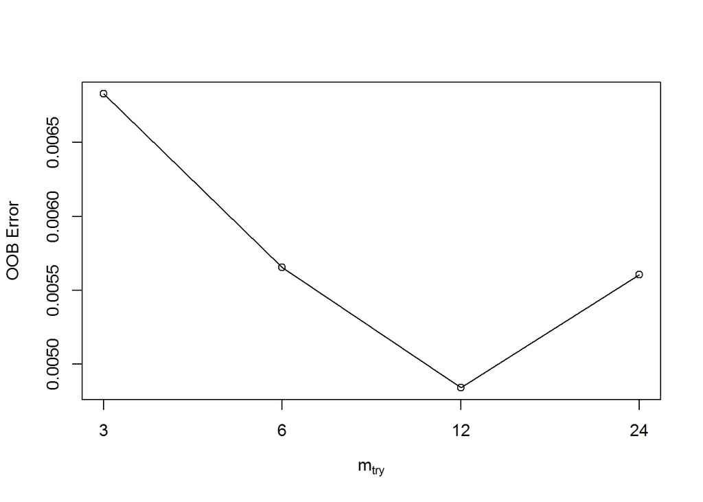

```r
modrf <- randomForest(classe ~ ., data=training,mtry=tune$mtry)
modrf
```

```
##
## Call:
##  randomForest(formula = classe ~ ., data = training, mtry = tune$mtry)
##                Type of random forest: classification
##                      Number of trees: 500
## No. of variables tried at each split: 12
##
##         OOB estimate of  error rate: 0.34%
## Confusion matrix:
##      A    B    C    D    E  class.error
## A 5577    2    0    0    1 0.0005376344
## B   12 3778    6    0    1 0.0050039505
## C    0   10 3408    4    0 0.0040911748
## D    0    0   21 3192    3 0.0074626866
## E    0    0    2    4 3601 0.0016634322
```

```r
answerrf <- predict(modrf,testing[,-length(training)])
```

Out of bagging error is below 0.5%. Very good prediction model has been obtained.

# Evaluation of prediction result

Comparing the prediction result of the test set. Exact exerceise classes of the test set are not known here, simply comparing the prediction result of two model, by counting how many of prediction results are agreed in two models.

```r
agree <- sum(answerSVM == answerrf)
agree
```

```
## [1] 20
```

Prediction results of SMV and randomForest algorithm are same in all 20 cases. Both model show good prediction performance. In this write-up, randomForest algorithm needs lesser CPU time, so using random forest algorithm is recommended.